# Colgate VS Crest

Beatriz Quevedo

2020-11-23

# Introducción

El análisis de intervención proporciona una herramienta que puede ser útil para evaluar el impacto de las iniciativas que la empresa, los competidores o terceros pueden realizar en el mix de mercado. En esta caso práctico, se considerará la lucha por la cuota de mercado entre la crema dental Colgate de Colgate-Palmolive y la crema dental Crest de Procter y Gamble.

# Grafición de las series

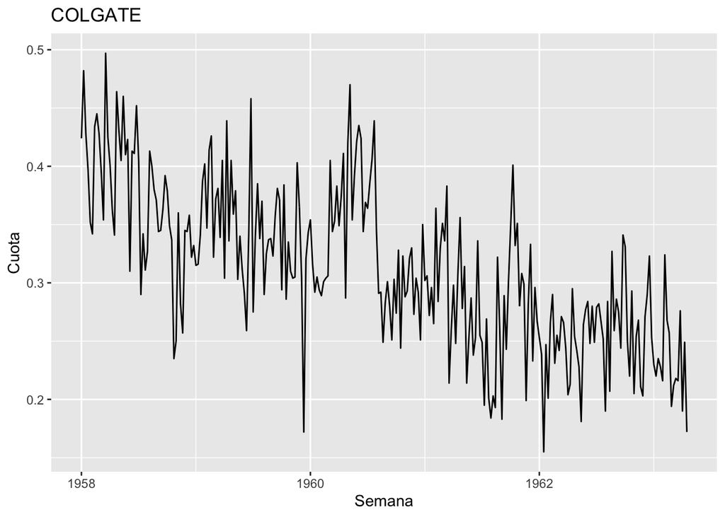

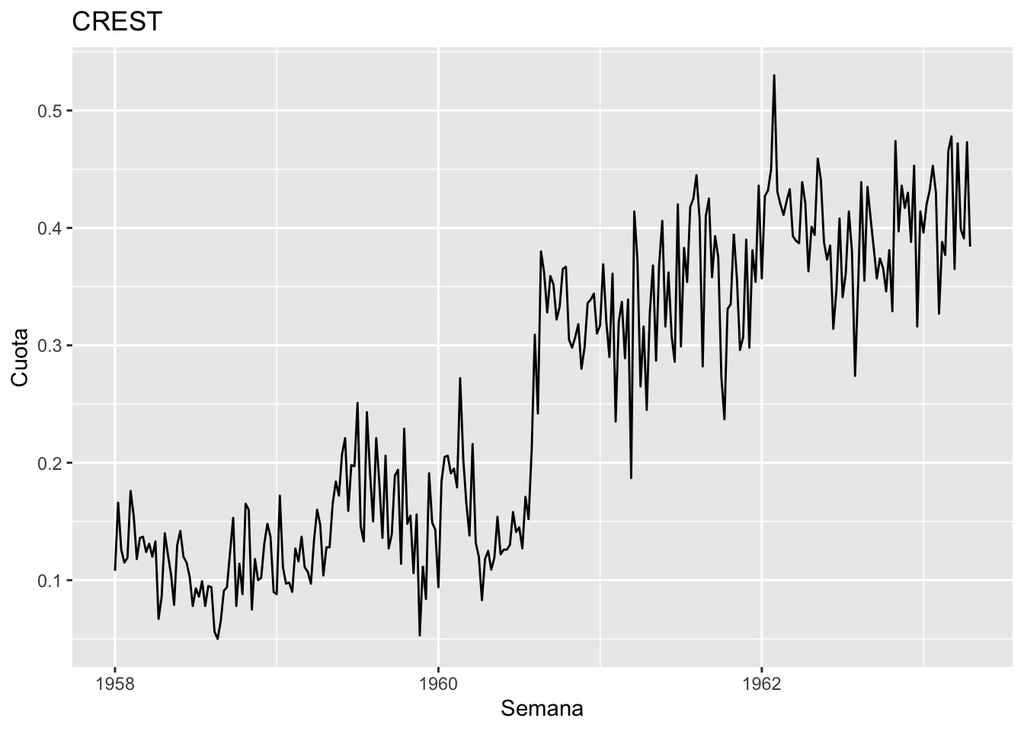

Como se puede comprobar en las gráficas, **Colgate** desde 1960 ha sufrido un decremento de su cuota de mercado, mientras que **Crest** ha aumentado.

Primero se realizará un test para ver si existe o no estacionariedad. La hipótesis nula será la no estacionariedad de los datos.

```
##
##  Augmented Dickey-Fuller Test
##
## data:  colgate.z
## Dickey-Fuller = -4.1783, Lag order = 6, p-value = 0.01
## alternative hypothesis: stationary
```

```
##
##  Augmented Dickey-Fuller Test
##
## data:  crest.z
## Dickey-Fuller = -3.4715, Lag order = 6, p-value = 0.04591
## alternative hypothesis: stationary
```

En ambos casos el p-valor es inferior a 0.05, por lo que se rechaza la hipótesis nula, por lo que se concluye que existe estacionariedad, y por lo tanto, los datos no serán tratados para forzar la estacionariedad.

# Modelo ARIMA

Para obtener el modelo se utilizará autoarima con una muestra de entrenamiento.

```
## Series: colgate.train
## ARIMA(0,1,1)(1,0,0)[52]
##
## Coefficients:
##           ma1    sar1
##       -0.7571  0.0232
## s.e.   0.0470  0.0682
##
## sigma^2 estimated as 0.00232:  log likelihood=418.63
## AIC=-831.25   AICc=-831.16   BIC=-820.58
##
## Training set error measures:
##                        ME       RMSE        MAE       MPE     MAPE      MASE
## Training set -0.002534821 0.04788855 0.03773876 -3.019377 12.77398 0.6038201
##                    ACF1
## Training set 0.05216089
```

```
## Series: crest.train
## ARIMA(0,1,1)
##
## Coefficients:
##           ma1
##       -0.6494
## s.e.   0.0448
##
## sigma^2 estimated as 0.002054:  log likelihood=434.08
## AIC=-864.15   AICc=-864.1   BIC=-857.04
##
## Training set error measures:
##                       ME       RMSE        MAE       MPE     MAPE      MASE
## Training set 0.003018071 0.04514444 0.03445351 -2.924537 17.27068 0.3800355
##                     ACF1
## Training set -0.04605961
```

# Análisis de los residuos

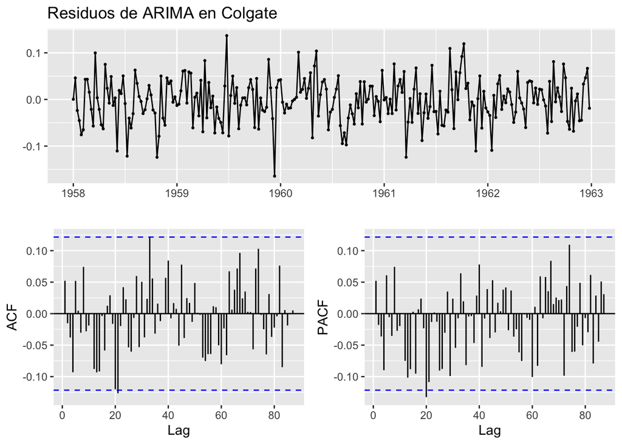

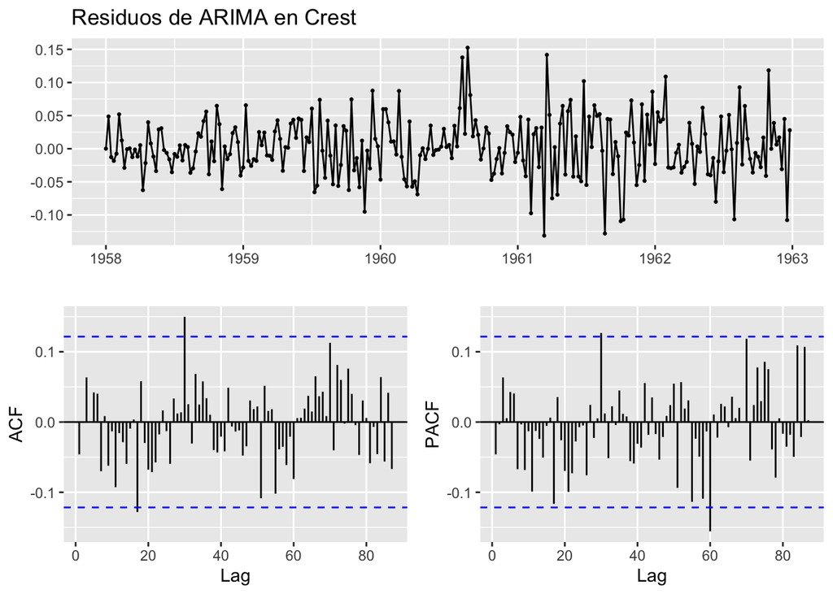

# Prueba de Ljung - Box

Este test es un tipo de prueba estadística que determina si, de un grupo cualquiera de autorrelaciones de una serie de tiempo, son diferentes de cero.

Su hipótesis nula afirma que los datos se distribuyen de manera independiente.

```
##
##  Box-Ljung test
##
## data:  fit.colgate$residuals
## X-squared = 3.463, df = 1, p-value = 0.06276
```

```
##
##  Box-Ljung test
##
## data:  fit.crest$residuals
## X-squared = 1.6315, df = 1, p-value = 0.2015
```

Como los p-valores se encuentran por encima del nivel de significacion, no se rechaza la independencia de las observaciones.

# Predicción

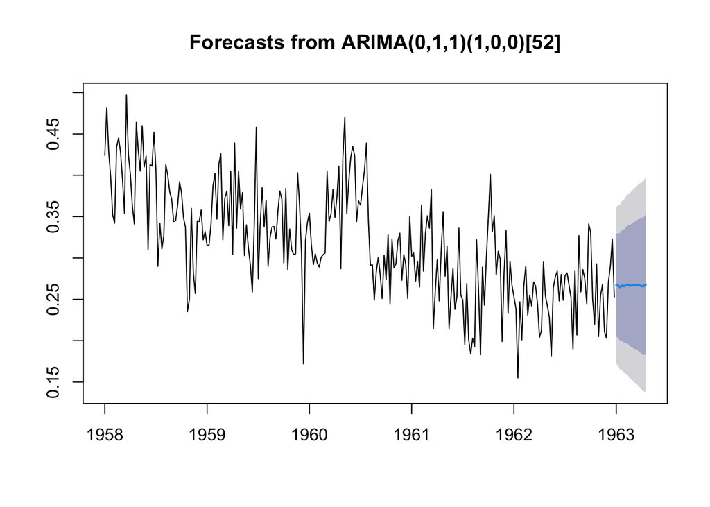

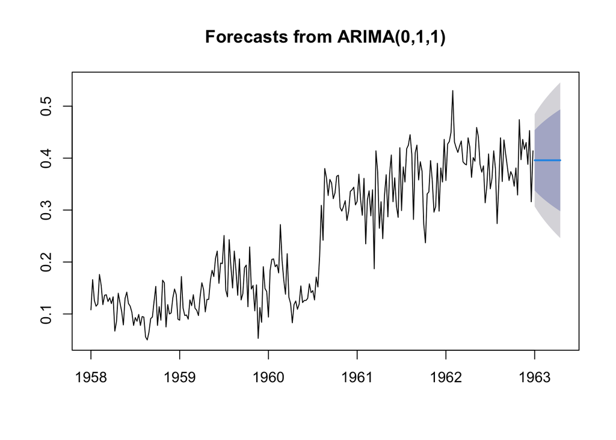

# Detección de outliers

```
## [1] "No AO detected"
```

```
##               [,1]       [,2]       [,3]
## ind     135.000000 136.000000 138.000000
## lambda2   3.918954   4.372891   4.005427
```

```
## [1] "No IO detected"
```

```
## [1] "No IO detected"
```

Hay tres outliers: en los puntos 135, 136 y 138. Mientras que el punto 135 muestra el cambio disruptivo en el mercado, los puntos 136 y 138 pueden ser fruto indirecto de este cambio, ya que son fechas muy próximas.

# Modelo ARIMAX

```
##
## Call:
## arimax(x = as.double(colgate.z), order = c(0, 1, 1), method = "ML", xtransf = data.frame(A60_step = 1 *
##     (seq(colgate.z)), A60_pulse = 1 * (seq(colgate.z))), transfer = list(c(0,
##     0), c(1, 0)))
##
## Coefficients:
##           ma1  A60_step-MA0  A60_pulse-AR1  A60_pulse-MA0
##       -0.7730        -4e-04              0        -0.0004
## s.e.   0.0455           NaN            NaN         0.0072
##
## sigma^2 estimated as 0.002256:  log likelihood = 447.31,  aic = -886.61
```

```
##
## Call:
## arimax(x = as.double(crest.z), order = c(0, 1, 1), xreg = data.frame(A60_3 = 1 *
##     (seq(crest.z) == 136), A60_3 = 1 * (seq(crest.z) == 138)), method = "ML",
##     xtransf = data.frame(A60_step = 1 * (seq(crest.z) >= 135), A60_pulse = 1 *
##         (seq(crest.z))), transfer = list(c(0, 0), c(0, 0)))
##
## Coefficients:
##           ma1   A60_3  A60_3.1  A60_step-MA0  A60_pulse-MA0
##       -0.7674  0.0205   0.0766        0.1346          5e-04
## s.e.   0.0476  0.0436   0.0420        0.0318          6e-04
##
## sigma^2 estimated as 0.001899:  log likelihood = 470.97,  aic = -931.94
```

```
## [1] "No AO detected"
```

```
## [1] "No IO detected"
```

```
## [1] "No AO detected"
```

```
## [1] "No IO detected"
```

# Función de transferencia

```
##
## Call:
## arimax(x = as.double(colgate.z), order = c(0, 1, 1), include.mean = TRUE, method = "ML",
##     xtransf = crest.z, transfer = list(c(0, 0)))
##
## Coefficients:
##           ma1  xtransf-MA0
##       -0.8381      -0.4884
## s.e.   0.0346       0.0530
##
## sigma^2 estimated as 0.001751:  log likelihood = 481.99,  aic = -959.97
```

```
##
## Call:
## arimax(x = as.double(colgate.z), order = c(0, 1, 1), include.mean = TRUE, method = "ML",
##     xtransf = crest.z, transfer = list(c(0, 0)))
##
## Coefficients:
##           ma1  xtransf-MA0
##       -0.8381      -0.4884
## s.e.   0.0346       0.0530
##
## sigma^2 estimated as 0.001751:  log likelihood = 481.99,  aic = -959.97
##
## Training set error measures:
##                       ME      RMSE        MAE       MPE     MAPE      MASE
## Training set -0.00136496 0.0417676 0.03229819 -2.196369 10.97291 0.6993702
##                    ACF1
## Training set 0.06132245
```

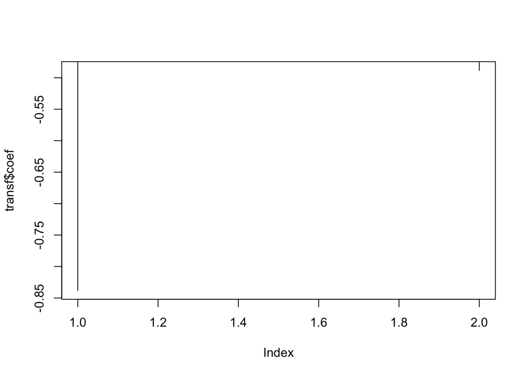